# Mid Exam

Ye Yuan

12/3/2019

# ● Section 1 - Mixed Model

## Instructions

Using the following data, produce a visualization with patient_days_admitted on the x-axis and dollar_spent_per_patient on the y-axis. After producing this visualization, explain what this relationship means and how this relationship might guide a decision.

After looking at the bivariate relationship in the previous visualization, add department to the visualization as a grouping variable. Does this change your interpretation of the relationship or add any expanded understanding? If so, how? Does this visualization offer any additional explanatory power over the more simple visualization? Explain.

## Solution

```r
sec1Link <- read.csv("https://www.nd.edu/~sberry5/data/visualizationData.csv")
summary(sec1Link)
```

```
##  dollar_spent_per_patient patient_days_admitted   department
##  Min.   : 641.6           Min.   : 1.00         cancer :21
##  1st Qu.:1112.4           1st Qu.: 8.50         cardiac:22
##  Median :1450.2           Median :15.00         general:84
##  Mean   :1515.6           Mean   :15.53
##  3rd Qu.:1820.1           3rd Qu.:23.00
##  Max.   :2795.6           Max.   :30.00
```

Relationship between patient_days_admitted and dollar_spent_per_patient

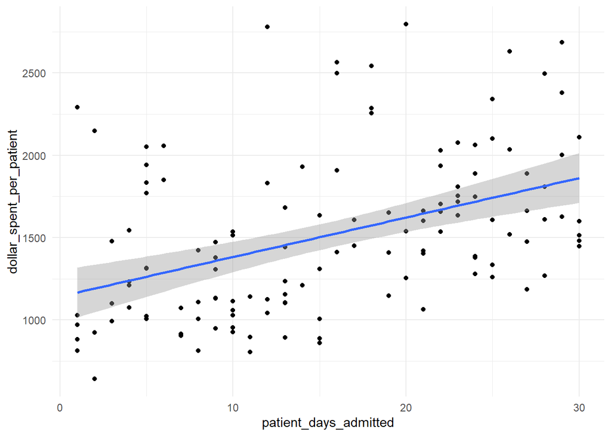

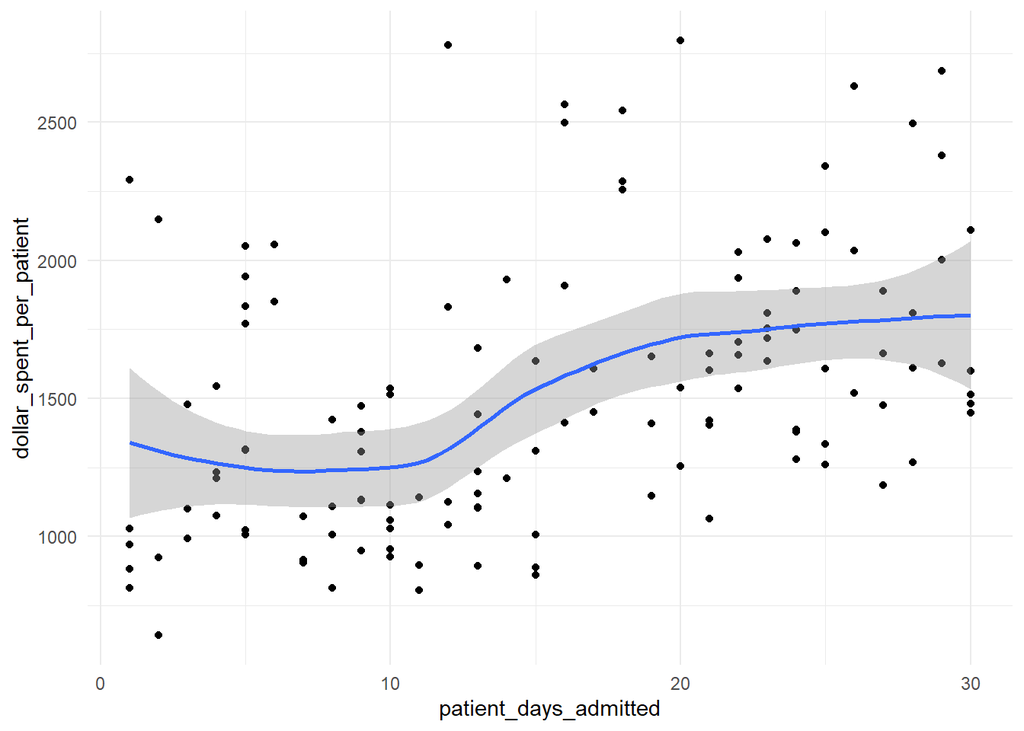

Decision: From the lm trend, we know,the more patient days admitted, the more money they spent per patient. But actually, we can see when the patient_days_admitted =8 or 9, the spent reaches the lowest. Also, during spent = 11~20, it increased most. And then, the slope decrease slightly. So, we can make decisions that if we want to cut the budget, the best length for patient to stay is 8 or 9 days.

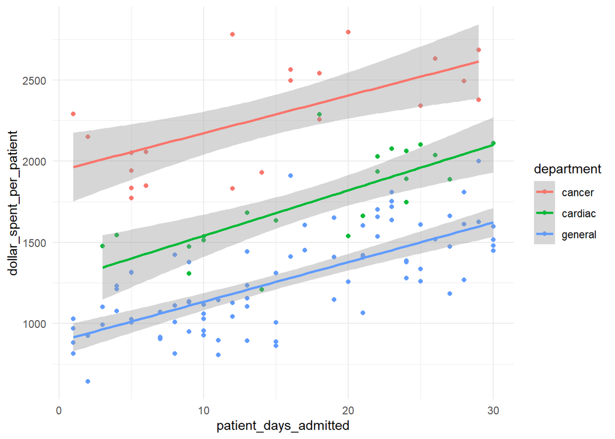

After we divided the department, we can find the cofficients of three lines are almost the same, but their intercept have large differences. Then we need to figure out which department acount for most.

[output not shown]

```r
library(merTools)
```

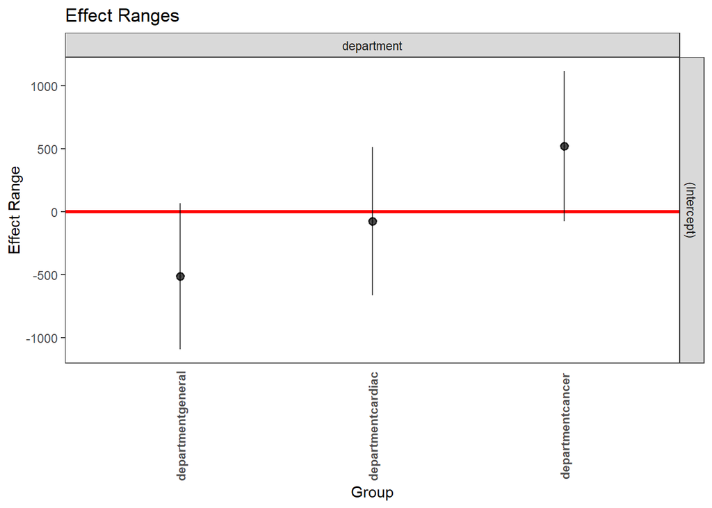

```r
plotREsim(REsim(riMod), labs = TRUE)
```